# NigerianCovid-19Forecast

## Objective of the Notebook

In this work the objective is to understand outbreak of COVID-19 in Nigeria, I carryout a Comparison of the cases in Nigeria with other African Countries, Futhermore I carryout a Comparison with worst affected countries in Europe and America and finally used Machine Learning and Time Series Forecasting models to give a short-term forecast.

## Let's get started

### Importing required Python Packages and Libraries

```python
import warnings
warnings.filterwarnings('ignore')
import pandas as pd
import matplotlib.pyplot as plt
import seaborn as sns
import numpy as np
import datetime as dt
from datetime import timedelta
from sklearn.preprocessing import PolynomialFeatures
from sklearn.linear_model import LinearRegression
from sklearn.svm import SVR
from statsmodels.tsa.api import Holt,SimpleExpSmoothing,ExponentialSmoothing
from sklearn.metrics import mean_squared_error,r2_score
import statsmodels.api as sm
from fbprophet import Prophet
```

### The dataset is obtained from the World Health Organization Records

```python
covid=pd.read_csv("../input/novel-corona-virus-2019-dataset/covid_19_data.csv")
covid.head()
```

|  | SNo | ObservationDate | Province/State | Country/Region | Last Update | Confirmed | Deaths | Recovered |
| --- | --- | --- | --- | --- | --- | --- | --- | --- |
| 0 | 1 | 01/22/2020 | Anhui | Mainland China | 1/22/2020 17:00 | 1.0 | 0.0 | 0.0 |
| 1 | 2 | 01/22/2020 | Beijing | Mainland China | 1/22/2020 17:00 | 14.0 | 0.0 | 0.0 |
| 2 | 3 | 01/22/2020 | Chongqing | Mainland China | 1/22/2020 17:00 | 6.0 | 0.0 | 0.0 |
| 3 | 4 | 01/22/2020 | Fujian | Mainland China | 1/22/2020 17:00 | 1.0 | 0.0 | 0.0 |
| 4 | 5 | 01/22/2020 | Gansu | Mainland China | 1/22/2020 17:00 | 0.0 | 0.0 | 0.0 |

```python
#Extracting Nigeria's data
covid_nigeria=covid[covid['Country/Region']=="Nigeria"]

#Extracting other countries for comparison of worst affected countries
covid_spain=covid[covid['Country/Region']=="Spain"]
covid_us=covid[covid['Country/Region']=="US"]
covid_italy=covid[covid['Country/Region']=="Italy"]
covid_iran=covid[covid['Country/Region']=="Iran"]
covid_france=covid[covid['Country/Region']=="France"]
covid_uk=covid[covid['Country/Region']=="UK"]

#Extracting data of other African countries
covid_ghana=covid[covid['Country/Region']=="Ghana"]
covid_south_africa=covid[covid['Country/Region']=="South Africa"]
covid_egypt=covid[covid['Country/Region']=="Egypt"]
covid_kenya=covid[covid['Country/Region']=="Kenya"]
covid_ethiopia=covid[covid["Country/Region"]=="Ethiopia"]
covid_senegal=covid[covid["Country/Region"]=="Senegal"]
```

```python
#Converting the date into Datetime format
covid_nigeria["ObservationDate"]=pd.to_datetime(covid_nigeria["ObservationDate"])
covid_spain["ObservationDate"]=pd.to_datetime(covid_spain["ObservationDate"])
covid_us["ObservationDate"]=pd.to_datetime(covid_us["ObservationDate"])
covid_italy["ObservationDate"]=pd.to_datetime(covid_italy["ObservationDate"])
covid_iran["ObservationDate"]=pd.to_datetime(covid_iran["ObservationDate"])
covid_france["ObservationDate"]=pd.to_datetime(covid_france["ObservationDate"])
covid_uk["ObservationDate"]=pd.to_datetime(covid_uk["ObservationDate"])

covid_ghana["ObservationDate"]=pd.to_datetime(covid_ghana["ObservationDate"])
covid_south_africa["ObservationDate"]=pd.to_datetime(covid_south_africa["ObservationDate"])
covid_egypt["ObservationDate"]=pd.to_datetime(covid_egypt["ObservationDate"])
covid_kenya["ObservationDate"]=pd.to_datetime(covid_kenya["ObservationDate"])
covid_ethiopia["ObservationDate"]=pd.to_datetime(covid_ethiopia["ObservationDate"])
covid_senegal["ObservationDate"]=pd.to_datetime(covid_senegal["ObservationDate"])
```

```python
#Grouping the data based on the Date
nigeria_datewise=covid_nigeria.groupby(["ObservationDate"]).agg({"Confirmed":'sum',"Recovered":'sum',"Deaths":'sum'})
spain_datewise=covid_spain.groupby(["ObservationDate"]).agg({"Confirmed":'sum',"Recovered":'sum',"Deaths":'sum'})
us_datewise=covid_us.groupby(["ObservationDate"]).agg({"Confirmed":'sum',"Recovered":'sum',"Deaths":'sum'})
italy_datewise=covid_italy.groupby(["ObservationDate"]).agg({"Confirmed":'sum',"Recovered":'sum',"Deaths":'sum'})
iran_datewise=covid_iran.groupby(["ObservationDate"]).agg({"Confirmed":'sum',"Recovered":'sum',"Deaths":'sum'})
france_datewise=covid_france.groupby(["ObservationDate"]).agg({"Confirmed":'sum',"Recovered":'sum',"Deaths":'sum'})
uk_datewise=covid_uk.groupby(["ObservationDate"]).agg({"Confirmed":'sum',"Recovered":'sum',"Deaths":'sum'})

ghana_datewise=covid_ghana.groupby(["ObservationDate"]).agg({"Confirmed":'sum',"Recovered":'sum',"Deaths":'sum'})
south_africa_datewise=covid_south_africa.groupby(["ObservationDate"]).agg({"Confirmed":'sum',"Recovered":'sum',"Deaths":'sum'})
egypt_datewise=covid_egypt.groupby(["ObservationDate"]).agg({"Confirmed":'sum',"Recovered":'sum',"Deaths":'sum'})
kenya_datewise=covid_kenya.groupby(["ObservationDate"]).agg({"Confirmed":'sum',"Recovered":'sum',"Deaths":'sum'})
ethiopia_datewise=covid_ethiopia.groupby(["ObservationDate"]).agg({"Confirmed":'sum',"Recovered":'sum',"Deaths":'sum'})
senegal_datewise=covid_senegal.groupby(["ObservationDate"]).agg({"Confirmed":'sum',"Recovered":'sum',"Deaths":'sum'})
```

```python
#Adding week column to perfom weekly analysis further ahead
nigeria_datewise["WeekofYear"]=nigeria_datewise.index.weekofyear
spain_datewise["WeekofYear"]=spain_datewise.index.weekofyear
us_datewise["WeekofYear"]=us_datewise.index.weekofyear
italy_datewise["WeekofYear"]=italy_datewise.index.weekofyear
iran_datewise["WeekofYear"]=iran_datewise.index.weekofyear
france_datewise["WeekofYear"]=france_datewise.index.weekofyear
uk_datewise["WeekofYear"]=uk_datewise.index.weekofyear

ghana_datewise["WeekofYear"]=ghana_datewise.index.weekofyear
south_africa_datewise["WeekofYear"]=south_africa_datewise.index.weekofyear
egypt_datewise["WeekofYear"]=egypt_datewise.index.weekofyear
kenya_datewise["WeekofYear"]=kenya_datewise.index.weekofyear
ethiopia_datewise["WeekofYear"]=ethiopia_datewise.index.weekofyear
senegal_datewise["WeekofYear"]=senegal_datewise.index.weekofyear
```

```python
nigeria_datewise["Days Since"]=(nigeria_datewise.index-nigeria_datewise.index[0])
nigeria_datewise["Days Since"]=nigeria_datewise["Days Since"].dt.days
```

```python
grouped_country=covid.groupby(["Country/Region","ObservationDate"]).agg({"Confirmed":'sum',"Recovered":'sum',"Deaths":'sum'})
```

```python
grouped_country["Active Cases"]=grouped_country["Confirmed"]-grouped_country["Recovered"]-grouped_country["Deaths"]
grouped_country["log_confirmed"]=np.log(grouped_country["Confirmed"])
grouped_country["log_active"]=np.log(grouped_country["Active Cases"])
```

## Exploratory Data Analysis for Nigeria

```python
print("Number of Confirmed Cases",nigeria_datewise["Confirmed"].iloc[-1])
print("Number of Recovered Cases",nigeria_datewise["Recovered"].iloc[-1])
print("Number of Death Cases",nigeria_datewise["Deaths"].iloc[-1])
print("Number of Active Cases",nigeria_datewise["Confirmed"].iloc[-1]-nigeria_datewise["Recovered"].iloc[-1]-nigeria_datewise["Deaths"].iloc[-1])
print("Number of Closed Cases",nigeria_datewise["Recovered"].iloc[-1]+nigeria_datewise["Deaths"].iloc[-1])
print("Approximate Number of Confirmed Cases per day",round(nigeria_datewise["Confirmed"].iloc[-1]/nigeria_datewise.shape[0]))
print("Approximate Number of Recovered Cases per day",round(nigeria_datewise["Recovered"].iloc[-1]/nigeria_datewise.shape[0]))
print("Approximate Number of Death Cases per day",round(nigeria_datewise["Deaths"].iloc[-1]/nigeria_datewise.shape[0]))
print("Number of New Cofirmed Cases in last 24 hours are",nigeria_datewise["Confirmed"].iloc[-1]-nigeria_datewise["Confirmed"].iloc[-2])
print("Number of New Recoverd Cases in last 24 hours are",nigeria_datewise["Recovered"].iloc[-1]-nigeria_datewise["Recovered"].iloc[-2])
print("Number of New Death Cases in last 24 hours are",nigeria_datewise["Deaths"].iloc[-1]-nigeria_datewise["Deaths"].iloc[-2])
```

```
Number of Confirmed Cases 11166.0
Number of Recovered Cases 3329.0
Number of Death Cases 315.0
Number of Active Cases 7522.0
Number of Closed Cases 3644.0
Approximate Number of Confirmed Cases per day 115.0
Approximate Number of Recovered Cases per day 34.0
Approximate Number of Death Cases per day 3.0
Number of New Cofirmed Cases in last 24 hours are 347.0
Number of New Recoverd Cases in last 24 hours are 89.0
Number of New Death Cases in last 24 hours are 1.0
```

#### Active Cases = Number of Confirmed Cases - Number of Recovered Cases - Number of Death Cases

#### Increase in number of Active Cases is probable an indication of Recovered case or Death case number is dropping in comparison to number of Confirmed Cases drastically. Will look for the conclusive evidence for the same in the notebook ahead.

[figure not shown]

```python
plt.figure(figsize=(15,5))
sns.barplot(x=nigeria_datewise.index.date,y=nigeria_datewise["Confirmed"]-nigeria_datewise["Recovered"]-nigeria_datewise["Deaths"])
plt.xticks(rotation=90)
plt.ylabel("Number of Cases")
plt.xlabel("Date")
plt.title("Distribution of Number of Active Cases in Nigeria From Feb. 28th - May 5rd")
```

#### Closed Cases = Number of Recovered Cases + Number of Death Cases

#### Increase in number of Closed classes imply either more patients are getting recovered from the disease or more pepole are dying because of COVID-19. Will look for conclusive evidence ahead.

[figure not shown]

```python
plt.figure(figsize=(15,5))
sns.barplot(x=nigeria_datewise.index.date,y=nigeria_datewise["Recovered"]+nigeria_datewise["Deaths"])
plt.xticks(rotation=90)
plt.ylabel("Number of Cases")
plt.xlabel("Date")
plt.title("Distribution of Number of Closed Cases in Nigeria From Feb. 28th - May 5rd")
```

#### Growth Rate of Confirmed, Recoverd and Death Cases

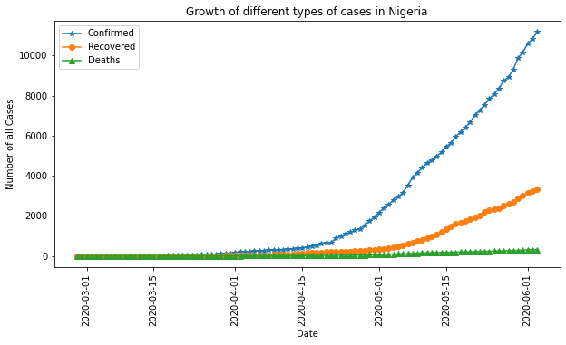

```python
plt.figure(figsize=(10,5))
plt.plot(nigeria_datewise["Confirmed"],label="Confirmed",marker='*')
plt.plot(nigeria_datewise["Recovered"],label="Recovered",marker='o')
plt.plot(nigeria_datewise["Deaths"],label="Deaths",marker="^")
plt.xticks(rotation=90)
plt.ylabel("Number of all Cases")
plt.xlabel("Date")
plt.title("Growth of different types of cases in Nigeria")
plt.legend()
```

Almost Exponential growth of Confirmed Cases in comparison to Recovered and Death Cases is a conclusive evidence why there is increase in number of Active Cases.

#### Recovery and Mortality Rate

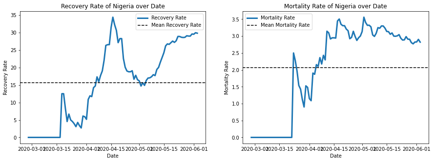

```python
fig, (ax1,ax2) = plt.subplots(1, 2,figsize=(15,5))
ax1.plot((nigeria_datewise["Recovered"]/nigeria_datewise["Confirmed"])*100,label="Recovery Rate",linewidth=3)
ax1.axhline(((nigeria_datewise["Recovered"]/nigeria_datewise["Confirmed"])*100).mean(),linestyle='--',color='black',label="Mean Recovery Rate")
ax1.set_xlabel("Date")
ax1.set_ylabel("Recovery Rate")
ax1.set_title("Recovery Rate of Nigeria over Date")
ax1.legend()
ax2.plot((nigeria_datewise["Deaths"]/nigeria_datewise["Confirmed"])*100,label="Mortality Rate",linewidth=3)
ax2.axhline(((nigeria_datewise["Deaths"]/nigeria_datewise["Confirmed"])*100).mean(),linestyle='--',color='black',label="Mean Mortality Rate")
ax2.set_xlabel("Date")
ax2.set_ylabel("Mortality Rate")
ax2.set_title("Mortality Rate of Nigeria over Date")
ax2.legend()
```

#### Mortality rate = (Number of Death Cases / Number of Confirmed Cases) x 100

#### Recovery Rate= (Number of Recoverd Cases / Number of Confirmed Cases) x 100

Slightly dipping Mortality Rate and increasing recovery rate is a positive sign

### Growth Factor

Growth factor is the factor by which a quantity multiplies itself over time. The formula used is:

**Formula: Every day's new (Confirmed,Recovered,Deaths) / new (Confirmed,Recovered,Deaths) on the previous day.**

A growth factor **above 1 indicates an increase correspoding cases**.

A growth factor **above 1 but trending downward** is a positive sign, whereas a **growth factor constantly above 1 is the sign of exponential growth**.

A growth factor **constant at 1 indicates there is no change in any kind of cases**.

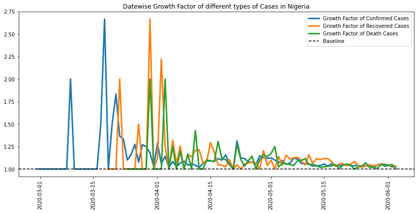

```python
plt.figure(figsize=(14,6))
plt.plot(nigeria_datewise["Confirmed"]/nigeria_datewise["Confirmed"].shift(),linewidth=3,label="Growth Factor of Confirmed Cases")
plt.plot(nigeria_datewise["Recovered"]/nigeria_datewise["Recovered"].shift(),linewidth=3,label="Growth Factor of Recovered Cases")
plt.plot(nigeria_datewise["Deaths"]/nigeria_datewise["Deaths"].shift(),linewidth=3,label="Growth Factor of Death Cases")
plt.axhline(1,linestyle='--',color='black',label="Baseline")
plt.legend()
plt.title("Datewise Growth Factor of different types of Cases in Nigeria")
plt.xticks(rotation=90)
```

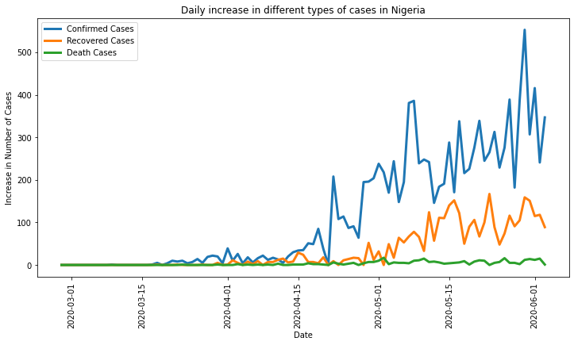

```python
plt.figure(figsize=(12,6))
plt.plot(nigeria_datewise["Confirmed"].diff().fillna(0),linewidth=3,label="Confirmed Cases")
plt.plot(nigeria_datewise["Recovered"].diff().fillna(0),linewidth=3,label="Recovered Cases")
plt.plot(nigeria_datewise["Deaths"].diff().fillna(0),linewidth=3,label="Death Cases")
plt.ylabel("Increase in Number of Cases")
plt.xlabel("Date")
plt.title("Daily increase in different types of cases in Nigeria")
plt.xticks(rotation=90)
plt.legend()
```

```python
week_num_nigeria=[]
nigeria_weekwise_confirmed=[]
nigeria_weekwise_recovered=[]
nigeria_weekwise_deaths=[]
w=1
for i in list(nigeria_datewise["WeekofYear"].unique()):
    nigeria_weekwise_confirmed.append(nigeria_datewise[nigeria_datewise["WeekofYear"]==i]["Confirmed"].iloc[-1])
    nigeria_weekwise_recovered.append(nigeria_datewise[nigeria_datewise["WeekofYear"]==i]["Recovered"].iloc[-1])
    nigeria_weekwise_deaths.append(nigeria_datewise[nigeria_datewise["WeekofYear"]==i]["Deaths"].iloc[-1])
    week_num_nigeria.append(w)
    w=w+1
```

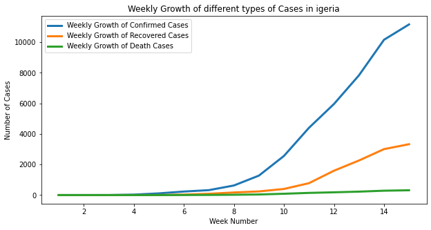

```python
plt.figure(figsize=(10,5))
plt.plot(week_num_nigeria,nigeria_weekwise_confirmed,linewidth=3,label="Weekly Growth of Confirmed Cases")
plt.plot(week_num_nigeria,nigeria_weekwise_recovered,linewidth=3,label="Weekly Growth of Recovered Cases")
plt.plot(week_num_nigeria,nigeria_weekwise_deaths,linewidth=3,label="Weekly Growth of Death Cases")
plt.xlabel('Week Number')
plt.ylabel("Number of Cases")
plt.title("Weekly Growth of different types of Cases in igeria")
plt.legend()
```

```
Average weekly increase in number of Confirmed Cases 744
Average weekly increase in number of Recovered Cases 222
Average weekly increase in number of Death Cases 21
```

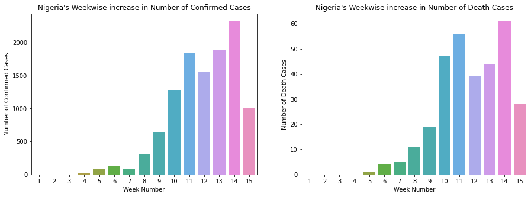

```python
print("Average weekly increase in number of Confirmed Cases",round(pd.Series(nigeria_weekwise_confirmed).diff().fillna(0).mean()))
print("Average weekly increase in number of Recovered Cases",round(pd.Series(nigeria_weekwise_recovered).diff().fillna(0).mean()))
print("Average weekly increase in number of Death Cases",round(pd.Series(nigeria_weekwise_deaths).diff().fillna(0).mean()))

fig, (ax1,ax2) = plt.subplots(1, 2,figsize=(15,5))
sns.barplot(x=week_num_nigeria,y=pd.Series(nigeria_weekwise_confirmed).diff().fillna(0),ax=ax1)
sns.barplot(x=week_num_nigeria,y=pd.Series(nigeria_weekwise_deaths).diff().fillna(0),ax=ax2)
ax1.set_xlabel("Week Number")
ax2.set_xlabel("Week Number")
ax1.set_ylabel("Number of Confirmed Cases")
ax2.set_ylabel("Number of Death Cases")
ax1.set_title("Nigeria's Weekwise increase in Number of Confirmed Cases")
ax2.set_title("Nigeria's Weekwise increase in Number of Death Cases")
```

### Comparison of Nigeria with Some African Countries

```python
n_countries=["Ghana","South Africa","Egypt","Kenya","Ethiopia","Senegal","Nigeria"]
comp_data=pd.concat([ghana_datewise.iloc[[-1]],south_africa_datewise.iloc[[-1]],egypt_datewise.iloc[[-1]],kenya_datewise.iloc[[-1]],
          ethiopia_datewise.iloc[[-1]],senegal_datewise.iloc[[-1]],nigeria_datewise.iloc[[-1]]])
comp_data.drop(["Days Since","WeekofYear"],1,inplace=True)
comp_data.index=n_countries
comp_data["Mortality"]=(comp_data["Deaths"]/comp_data["Confirmed"])*100
comp_data["Recovery"]=(comp_data["Recovered"]/comp_data["Confirmed"])*100
comp_data["Survival Probability"]=(1-(comp_data["Deaths"]/comp_data["Confirmed"]))*100
comp_data.sort_values(["Confirmed"],ascending=False)
```

|  | Confirmed | Deaths | Recovered | Mortality | Recovery | Survival Probability |
| --- | --- | --- | --- | --- | --- | --- |
| South Africa | 37525.0 | 792.0 | 19682.0 | 2.110593 | 52.450366 | 97.889407 |
| Egypt | 28615.0 | 1088.0 | 7350.0 | 3.802202 | 25.685829 | 96.197798 |
| Nigeria | 11166.0 | 315.0 | 3329.0 | 2.821064 | 29.813720 | 97.178936 |
| Ghana | 8548.0 | 38.0 | 3132.0 | 0.444548 | 36.640150 | 99.555452 |
| Senegal | 3932.0 | 45.0 | 2063.0 | 1.144456 | 52.466938 | 98.855544 |
| Kenya | 2216.0 | 74.0 | 553.0 | 3.339350 | 24.954874 | 96.660650 |
| Ethiopia | 1486.0 | 17.0 | 246.0 | 1.144011 | 16.554509 | 98.855989 |

```python
print("South Africa reported it's first confirm case on: ",south_africa_datewise.index[0].date())
print("Egypt reported it's first confirm case on: ",egypt_datewise.index[0].date())
print("Nigeria reported it's first confirm case on: ",nigeria_datewise.index[0].date())
print("Ghana reported it's first confirm case on: ",ghana_datewise.index[0].date())
print("Senegal reported it's first confirm case on: ",senegal_datewise.index[0].date())
print("Kenya reported it's first confirm case on: ",kenya_datewise.index[0].date())
print("Ethiopia reported it's first confirm case on: ",ethiopia_datewise.index[0].date())
```

```
South Africa reported it's first confirm case on:  2020-03-05
Egypt reported it's first confirm case on:  2020-02-14
Nigeria reported it's first confirm case on:  2020-02-28
Ghana reported it's first confirm case on:  2020-03-14
Senegal reported it's first confirm case on:  2020-03-02
Kenya reported it's first confirm case on:  2020-03-13
Ethiopia reported it's first confirm case on:  2020-03-13
```

### First Deaths

```python
print("South Africa reported it's first death case on: ",south_africa_datewise[south_africa_datewise["Deaths"]>0].index[0].date())
print("Egypt reported it's first death case on: ",egypt_datewise[egypt_datewise["Deaths"]>0].index[0].date())
print("Nigeria reported it's first death case on: ",nigeria_datewise[nigeria_datewise["Deaths"]>0].index[0].date())
print("Ghana reported it's first death case on: ",ghana_datewise[ghana_datewise["Deaths"]>0].index[0].date())
print("Senegal reported it's first death case on: ",senegal_datewise[senegal_datewise["Deaths"]>0].index[0].date())
print("Kenya reported it's first death case on: ",kenya_datewise[kenya_datewise["Deaths"]>0].index[0].date())
print("Ethiopia reported it's first death case on: ",ethiopia_datewise[ethiopia_datewise["Deaths"]>0].index[0].date())
```

```
South Africa reported it's first death case on:  2020-03-27
Egypt reported it's first death case on:  2020-03-08
Nigeria reported it's first death case on:  2020-03-23
Ghana reported it's first death case on:  2020-03-21
Senegal reported it's first death case on:  2020-04-01
Kenya reported it's first death case on:  2020-03-26
Ethiopia reported it's first death case on:  2020-04-05
```

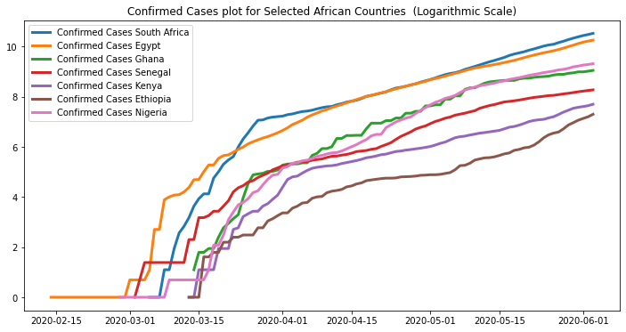

```python
plt.figure(figsize=(12,6))
plt.plot(np.log(south_africa_datewise["Confirmed"]),linewidth=3,label="Confirmed Cases South Africa")
plt.plot(np.log(egypt_datewise["Confirmed"]),linewidth=3,label="Confirmed Cases Egypt")
plt.plot(np.log(ghana_datewise["Confirmed"]),linewidth=3,label="Confirmed Cases Ghana")
plt.plot(np.log(senegal_datewise["Confirmed"]),linewidth=3,label="Confirmed Cases Senegal")
plt.plot(np.log(kenya_datewise["Confirmed"]),linewidth=3,label="Confirmed Cases Kenya")
plt.plot(np.log(ethiopia_datewise["Confirmed"]),linewidth=3,label="Confirmed Cases Ethiopia")
plt.plot(np.log(nigeria_datewise["Confirmed"]),linewidth=3,label="Confirmed Cases Nigeria")
plt.legend(loc=2)
plt.title("Confirmed Cases plot for Selected African Countries  (Logarithmic Scale)")
```

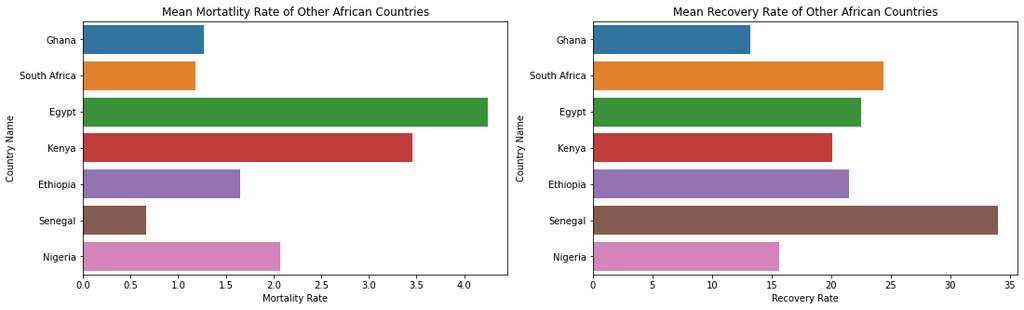

```python
fig, (ax1,ax2) = plt.subplots(1, 2,figsize=(18,5))
mean_mortality=[((ghana_datewise["Deaths"]/ghana_datewise["Confirmed"])*100).mean(),((south_africa_datewise["Deaths"]/south_africa_datewise["Confirmed"])*100).mean(),
               ((egypt_datewise["Deaths"]/egypt_datewise["Confirmed"])*100).mean(),((kenya_datewise["Deaths"]/kenya_datewise["Confirmed"])*100).mean(),
               ((ethiopia_datewise["Deaths"]/ethiopia_datewise["Confirmed"])*100).mean(),((senegal_datewise["Deaths"]/senegal_datewise["Confirmed"])*100).mean(),
               ((nigeria_datewise["Deaths"]/nigeria_datewise["Confirmed"])*100).mean()]
mean_recovery=[((ghana_datewise["Recovered"]/ghana_datewise["Confirmed"])*100).mean(),((south_africa_datewise["Recovered"]/south_africa_datewise["Confirmed"])*100).mean(),
               ((egypt_datewise["Recovered"]/egypt_datewise["Confirmed"])*100).mean(),((kenya_datewise["Recovered"]/kenya_datewise["Confirmed"])*100).mean(),
               ((ethiopia_datewise["Recovered"]/ethiopia_datewise["Confirmed"])*100).mean(),((senegal_datewise["Recovered"]/senegal_datewise["Confirmed"])*100).mean(),
               ((nigeria_datewise["Recovered"]/nigeria_datewise["Confirmed"])*100).mean()]

comp_data["Mean Mortality Rate"]=mean_mortality
comp_data["Mean Recovery Rate"]=mean_recovery


sns.barplot(x=comp_data["Mean Mortality Rate"],y=comp_data.index,ax=ax1)
ax1.set_title("Mean Mortatlity Rate of Other African Countries")
ax1.set_ylabel("Country Name")
ax1.set_xlabel("Mortality Rate")
sns.barplot(x=comp_data["Mean Recovery Rate"],y=comp_data.index,ax=ax2)
ax2.set_title("Mean Recovery Rate of Other African Countries")
ax2.set_ylabel("Country Name")
ax2.set_xlabel("Recovery Rate")
```

```python
country_names=["Spain","US","Italy","Iran","France","UK","Nigeria"]
country_data=pd.concat([spain_datewise.iloc[[-1]],us_datewise.iloc[[-1]],italy_datewise.iloc[[-1]],iran_datewise.iloc[[-1]],
          france_datewise.iloc[[-1]],uk_datewise.iloc[[-1]],nigeria_datewise.iloc[[-1]]])
country_data=country_data.drop(["Days Since","WeekofYear"],1)
country_data["Mortality"]=(country_data["Deaths"]/country_data["Confirmed"])*100
country_data["Recovery"]=(country_data["Recovered"]/country_data["Confirmed"])*100
country_data.index=country_names
country_data
```

|  | Confirmed | Deaths | Recovered | Mortality | Recovery |
| --- | --- | --- | --- | --- | --- |
| Spain | 240326.0 | 27128.0 | 150376.0 | 11.288000 | 62.571673 |
| US | 1851520.0 | 107175.0 | 479258.0 | 5.788487 | 25.884571 |
| Italy | 233836.0 | 33601.0 | 160938.0 | 14.369473 | 68.825160 |
| Iran | 160696.0 | 8012.0 | 125206.0 | 4.985812 | 77.914821 |
| France | 192330.0 | 29024.0 | 69573.0 | 15.090729 | 36.173764 |
| UK | 281270.0 | 39811.0 | 1212.0 | 14.154016 | 0.430903 |
| Nigeria | 11166.0 | 315.0 | 3329.0 | 2.821064 | 29.813720 |

```
It took 45 days in Spain to reach number of Confirmed Cases equivalent to Nigeria
It took 57 days in USA to reach number of Confirmed Cases equivalent to Nigeria
It took 40 days in Italy to reach number of Confirmed Cases equivalent to Nigeria
It took 23 days in Iran to reach number of Confirmed Cases equivalent to Nigeria
It took 56 days in France to reach number of Confirmed Cases equivalent to Nigeria
It took 55 days in United Kingdom to reach number of Confirmed Cases equivalent to Nigeria
It took 97 days in India to reach 11166.0 Confirmed Cases
```

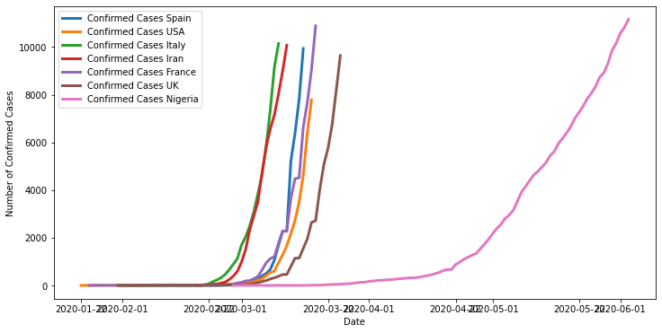

```python
max_confirm_nigeria=nigeria_datewise["Confirmed"].iloc[-1]
print("It took",spain_datewise[(spain_datewise["Confirmed"]>0)&(spain_datewise["Confirmed"]<=max_confirm_nigeria)].shape[0],"days in Spain to reach number of Confirmed Cases equivalent to Nigeria")
print("It took",us_datewise[(us_datewise["Confirmed"]>0)&(us_datewise["Confirmed"]<=max_confirm_nigeria)].shape[0],"days in USA to reach number of Confirmed Cases equivalent to Nigeria")
print("It took",italy_datewise[(italy_datewise["Confirmed"]>0)&(italy_datewise["Confirmed"]<=max_confirm_nigeria)].shape[0],"days in Italy to reach number of Confirmed Cases equivalent to Nigeria")
print("It took",iran_datewise[(iran_datewise["Confirmed"]>0)&(iran_datewise["Confirmed"]<=max_confirm_nigeria)].shape[0],"days in Iran to reach number of Confirmed Cases equivalent to Nigeria")
print("It took",france_datewise[(france_datewise["Confirmed"]>0)&(france_datewise["Confirmed"]<=max_confirm_nigeria)].shape[0],"days in France to reach number of Confirmed Cases equivalent to Nigeria")
print("It took",uk_datewise[(uk_datewise["Confirmed"]>0)&(uk_datewise["Confirmed"]<=max_confirm_nigeria)].shape[0],"days in United Kingdom to reach number of Confirmed Cases equivalent to Nigeria")
print("It took",nigeria_datewise[nigeria_datewise["Confirmed"]>0].shape[0],"days in India to reach",max_confirm_nigeria,"Confirmed Cases")

plt.figure(figsize=(12,6))
max_confirm_nigeria=nigeria_datewise["Confirmed"].iloc[-1]
plt.plot(spain_datewise[spain_datewise["Confirmed"]<=max_confirm_nigeria]["Confirmed"],label="Confirmed Cases Spain",linewidth=3)
plt.plot(us_datewise[us_datewise["Confirmed"]<=max_confirm_nigeria]["Confirmed"],label="Confirmed Cases USA",linewidth=3)
plt.plot(italy_datewise[italy_datewise["Confirmed"]<=max_confirm_nigeria]["Confirmed"],label="Confirmed Cases Italy",linewidth=3)
plt.plot(iran_datewise[iran_datewise["Confirmed"]<=max_confirm_nigeria]["Confirmed"],label="Confirmed Cases Iran",linewidth=3)
plt.plot(france_datewise[france_datewise["Confirmed"]<=max_confirm_nigeria]["Confirmed"],label="Confirmed Cases France",linewidth=3)
plt.plot(uk_datewise[uk_datewise["Confirmed"]<=max_confirm_nigeria]["Confirmed"],label="Confirmed Cases UK",linewidth=3)
plt.plot(nigeria_datewise["Confirmed"],label="Confirmed Cases Nigeria",linewidth=3)
plt.ylabel("Number of Confirmed Cases")
plt.xlabel("Date")
plt.legend()
```

### Weekly Comparisons

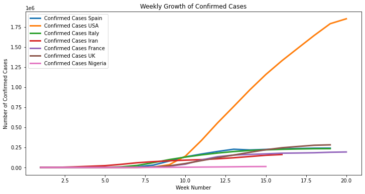

```python
week_num_spain=[]
spain_weekwise_confirmed=[]
spain_weekwise_recovered=[]
spain_weekwise_deaths=[]
w=1
for i in list(spain_datewise["WeekofYear"].unique()):
    spain_weekwise_confirmed.append(spain_datewise[spain_datewise["WeekofYear"]==i]["Confirmed"].iloc[-1])
    spain_weekwise_recovered.append(spain_datewise[spain_datewise["WeekofYear"]==i]["Recovered"].iloc[-1])
    spain_weekwise_deaths.append(spain_datewise[spain_datewise["WeekofYear"]==i]["Deaths"].iloc[-1])
    week_num_spain.append(w)
    w=w+1

week_num_us=[]
us_weekwise_confirmed=[]
us_weekwise_recovered=[]
us_weekwise_deaths=[]
w=1
for i in list(us_datewise["WeekofYear"].unique()):
    us_weekwise_confirmed.append(us_datewise[us_datewise["WeekofYear"]==i]["Confirmed"].iloc[-1])
    us_weekwise_recovered.append(us_datewise[us_datewise["WeekofYear"]==i]["Recovered"].iloc[-1])
    us_weekwise_deaths.append(us_datewise[us_datewise["WeekofYear"]==i]["Deaths"].iloc[-1])
    week_num_us.append(w)
    w=w+1

week_num_italy=[]
italy_weekwise_confirmed=[]
italy_weekwise_recovered=[]
italy_weekwise_deaths=[]
w=1
for i in list(italy_datewise["WeekofYear"].unique()):
    italy_weekwise_confirmed.append(italy_datewise[italy_datewise["WeekofYear"]==i]["Confirmed"].iloc[-1])
    italy_weekwise_recovered.append(italy_datewise[italy_datewise["WeekofYear"]==i]["Recovered"].iloc[-1])
    italy_weekwise_deaths.append(italy_datewise[italy_datewise["WeekofYear"]==i]["Deaths"].iloc[-1])
    week_num_italy.append(w)
    w=w+1

week_num_iran=[]
iran_weekwise_confirmed=[]
iran_weekwise_recovered=[]
iran_weekwise_deaths=[]
w=1
for i in list(iran_datewise["WeekofYear"].unique()):
    iran_weekwise_confirmed.append(iran_datewise[iran_datewise["WeekofYear"]==i]["Confirmed"].iloc[-1])
    iran_weekwise_recovered.append(iran_datewise[iran_datewise["WeekofYear"]==i]["Recovered"].iloc[-1])
    iran_weekwise_deaths.append(iran_datewise[iran_datewise["WeekofYear"]==i]["Deaths"].iloc[-1])
    week_num_iran.append(w)
    w=w+1

week_num_france=[]
france_weekwise_confirmed=[]
france_weekwise_recovered=[]
france_weekwise_deaths=[]
w=1
for i in list(france_datewise["WeekofYear"].unique()):
    france_weekwise_confirmed.append(france_datewise[france_datewise["WeekofYear"]==i]["Confirmed"].iloc[-1])
    france_weekwise_recovered.append(france_datewise[france_datewise["WeekofYear"]==i]["Recovered"].iloc[-1])
    france_weekwise_deaths.append(france_datewise[france_datewise["WeekofYear"]==i]["Deaths"].iloc[-1])
    week_num_france.append(w)
    w=w+1

week_num_uk=[]
uk_weekwise_confirmed=[]
uk_weekwise_recovered=[]
uk_weekwise_deaths=[]
w=1
for i in list(uk_datewise["WeekofYear"].unique()):
    uk_weekwise_confirmed.append(uk_datewise[uk_datewise["WeekofYear"]==i]["Confirmed"].iloc[-1])
    uk_weekwise_recovered.append(uk_datewise[uk_datewise["WeekofYear"]==i]["Recovered"].iloc[-1])
    uk_weekwise_deaths.append(uk_datewise[uk_datewise["WeekofYear"]==i]["Deaths"].iloc[-1])
    week_num_uk.append(w)
    w=w+1

week_num_nigeria=[]
nigeria_weekwise_confirmed=[]
nigeria_weekwise_recovered=[]
nigeria_weekwise_deaths=[]
w=1
for i in list(nigeria_datewise["WeekofYear"].unique()):
    nigeria_weekwise_confirmed.append(nigeria_datewise[nigeria_datewise["WeekofYear"]==i]["Confirmed"].iloc[-1])
    nigeria_weekwise_recovered.append(nigeria_datewise[nigeria_datewise["WeekofYear"]==i]["Recovered"].iloc[-1])
    nigeria_weekwise_deaths.append(nigeria_datewise[uk_datewise["WeekofYear"]==i]["Deaths"].iloc[-1])
    week_num_nigeria.append(w)
    w=w+1

plt.figure(figsize=(12,6))
plt.plot(week_num_spain,spain_weekwise_confirmed,linewidth=3,label="Confirmed Cases Spain")
plt.plot(week_num_us,us_weekwise_confirmed,linewidth=3,label="Confirmed Cases USA")
plt.plot(week_num_italy,italy_weekwise_confirmed,linewidth=3,label="Confirmed Cases Italy")
plt.plot(week_num_iran,iran_weekwise_confirmed,linewidth=3,label="Confirmed Cases Iran")
plt.plot(week_num_france,france_weekwise_confirmed,linewidth=3,label="Confirmed Cases France")
plt.plot(week_num_uk,uk_weekwise_confirmed,linewidth=3,label="Confirmed Cases UK")
plt.plot(week_num_nigeria,nigeria_weekwise_confirmed,linewidth=3,label="Confirmed Cases Nigeria")
plt.title("Weekly Growth of Confirmed Cases")
plt.xlabel("Week Number")
plt.ylabel("Number of Confirmed Cases")
plt.legend()
```

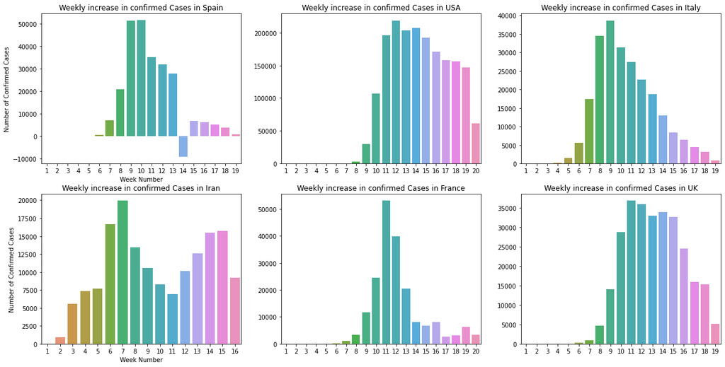

```python
fig, ((ax1,ax2,ax3),(ax4,ax5,ax6)) = plt.subplots(2, 3,figsize=(20,10))
sns.barplot(week_num_spain,pd.Series(spain_weekwise_confirmed).diff().fillna(0),ax=ax1)
ax1.set_title("Weekly increase in confirmed Cases in Spain")
ax1.set_ylabel("Number of Confirmed Cases")
ax1.set_xlabel("Week Number")
sns.barplot(week_num_us,pd.Series(us_weekwise_confirmed).diff().fillna(0),ax=ax2)
ax2.set_title("Weekly increase in confirmed Cases in USA")
sns.barplot(week_num_italy,pd.Series(italy_weekwise_confirmed).diff().fillna(0),ax=ax3)
ax3.set_title("Weekly increase in confirmed Cases in Italy")
sns.barplot(week_num_iran,pd.Series(iran_weekwise_confirmed).diff().fillna(0),ax=ax4)
ax4.set_title("Weekly increase in confirmed Cases in Iran")
ax4.set_ylabel("Number of Confirmed Cases")
ax4.set_xlabel("Week Number")
sns.barplot(week_num_france,pd.Series(france_weekwise_confirmed).diff().fillna(0),ax=ax5)
ax5.set_title("Weekly increase in confirmed Cases in France")
sns.barplot(week_num_uk,pd.Series(uk_weekwise_confirmed).diff().fillna(0),ax=ax6)
ax6.set_title("Weekly increase in confirmed Cases in UK")
```

## Machine Learning Predictions

```python
train_ml=nigeria_datewise.iloc[:int(nigeria_datewise.shape[0]*0.95)]
valid_ml=nigeria_datewise.iloc[int(nigeria_datewise.shape[0]*0.95):]
model_scores=[]
```

```python
poly = PolynomialFeatures(degree = 9)
```

```python
train_poly=poly.fit_transform(np.array(train_ml["Days Since"]).reshape(-1,1))
valid_poly=poly.fit_transform(np.array(valid_ml["Days Since"]).reshape(-1,1))
y=train_ml["Confirmed"]
```

```python
linreg=LinearRegression(normalize=True)
linreg.fit(train_poly,y)
```

```
LinearRegression(copy_X=True, fit_intercept=True, n_jobs=None, normalize=True)
```

```python
prediction_poly=linreg.predict(valid_poly)
rmse_poly=np.sqrt(mean_squared_error(valid_ml["Confirmed"],prediction_poly))
model_scores.append(rmse_poly)
print("Root Mean Squared Error for Polynomial Regression: ",rmse_poly)
```

```
Root Mean Squared Error for Polynomial Regression:  154.79122346293605
```

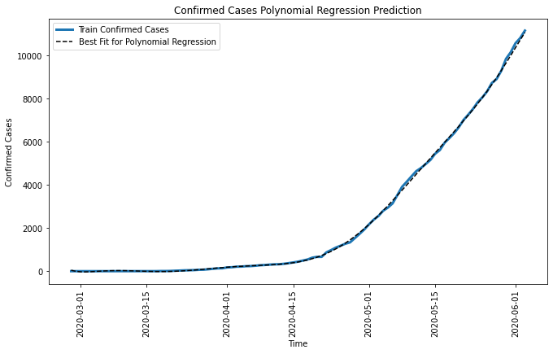

```python
comp_data=poly.fit_transform(np.array(nigeria_datewise["Days Since"]).reshape(-1,1))
plt.figure(figsize=(11,6))
predictions_poly=linreg.predict(comp_data)
plt.plot(nigeria_datewise["Confirmed"],label="Train Confirmed Cases",linewidth=3)
plt.plot(nigeria_datewise.index,predictions_poly, linestyle='--',label="Best Fit for Polynomial Regression",color='black')
plt.xlabel('Time')
plt.ylabel('Confirmed Cases')
plt.title("Confirmed Cases Polynomial Regression Prediction")
plt.xticks(rotation=90)
plt.legend()
```

```python
new_date=[]
new_prediction_poly=[]
for i in range(1,18):
    new_date.append(nigeria_datewise.index[-1]+timedelta(days=i))
    new_date_poly=poly.fit_transform(np.array(nigeria_datewise["Days Since"].max()+i).reshape(-1,1))
    new_prediction_poly.append(linreg.predict(new_date_poly)[0])
```

```python
model_predictions=pd.DataFrame(zip(new_date,new_prediction_poly),columns=["Date","Polynomial Regression Prediction"])
model_predictions.head(20)
```

|  | Date | Polynomial Regression Prediction |
| --- | --- | --- |
| 0 | 2020-06-04 | 11406.423481 |
| 1 | 2020-06-05 | 11699.589635 |
| 2 | 2020-06-06 | 11938.812156 |
| 3 | 2020-06-07 | 12100.642951 |
| 4 | 2020-06-08 | 12156.170057 |
| 5 | 2020-06-09 | 12070.186614 |
| 6 | 2020-06-10 | 11800.274780 |
| 7 | 2020-06-11 | 11295.798881 |
| 8 | 2020-06-12 | 10496.801803 |
| 9 | 2020-06-13 | 9332.798440 |
| 10 | 2020-06-14 | 7721.459727 |
| 11 | 2020-06-15 | 5567.180583 |
| 12 | 2020-06-16 | 2759.524806 |
| 13 | 2020-06-17 | -828.460279 |
| 14 | 2020-06-18 | -5342.066880 |
| 15 | 2020-06-19 | -10946.895220 |
| 16 | 2020-06-20 | -17830.975460 |

### Support Vector Machine

```python
train_ml=nigeria_datewise.iloc[:int(nigeria_datewise.shape[0]*0.95)]
valid_ml=nigeria_datewise.iloc[int(nigeria_datewise.shape[0]*0.95):]
```

```python
svm=SVR(C=1,degree=6,kernel='poly')
```

```python
svm.fit(np.array(train_ml["Days Since"]).reshape(-1,1),train_ml["Confirmed"])
```

```
SVR(C=1, cache_size=200, coef0=0.0, degree=6, epsilon=0.1, gamma='scale',
    kernel='poly', max_iter=-1, shrinking=True, tol=0.001, verbose=False)
```

```python
prediction_svm=svm.predict(np.array(valid_ml["Days Since"]).reshape(-1,1))
rmse_svm=np.sqrt(mean_squared_error(prediction_svm,valid_ml["Confirmed"]))
model_scores.append(rmse_svm)
print("Root Mean Square Error for SVR Model: ",rmse_svm)
```

```
Root Mean Square Error for SVR Model:  4232.85100071331
```

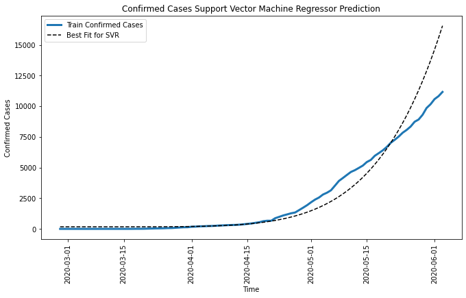

```python
plt.figure(figsize=(11,6))
predictions=svm.predict(np.array(nigeria_datewise["Days Since"]).reshape(-1,1))
plt.plot(nigeria_datewise["Confirmed"],label="Train Confirmed Cases",linewidth=3)
plt.plot(nigeria_datewise.index,predictions, linestyle='--',label="Best Fit for SVR",color='black')
plt.xlabel('Time')
plt.ylabel('Confirmed Cases')
plt.title("Confirmed Cases Support Vector Machine Regressor Prediction")
plt.xticks(rotation=90)
plt.legend()
```

```python
new_date=[]
new_prediction_svm=[]
for i in range(1,18):
    new_date.append(nigeria_datewise.index[-1]+timedelta(days=i))
    new_prediction_svm.append(svm.predict(np.array(nigeria_datewise["Days Since"].max()+i).reshape(-1,1))[0])
```

```python
model_predictions["SVM Prediction"]=new_prediction_svm
model_predictions.head(20)
```

|  | Date | Polynomial Regression Prediction | SVM Prediction |
| --- | --- | --- | --- |
| 0 | 2020-06-04 | 11406.423481 | 17610.941709 |
| 1 | 2020-06-05 | 11699.589635 | 18717.890762 |
| 2 | 2020-06-06 | 11938.812156 | 19882.780819 |
| 3 | 2020-06-07 | 12100.642951 | 21108.013136 |
| 4 | 2020-06-08 | 12156.170057 | 22396.062848 |
| 5 | 2020-06-09 | 12070.186614 | 23749.480463 |
| 6 | 2020-06-10 | 11800.274780 | 25170.893382 |
| 7 | 2020-06-11 | 11295.798881 | 26663.007425 |
| 8 | 2020-06-12 | 10496.801803 | 28228.608381 |
| 9 | 2020-06-13 | 9332.798440 | 29870.563562 |
| 10 | 2020-06-14 | 7721.459727 | 31591.823384 |
| 11 | 2020-06-15 | 5567.180583 | 33395.422953 |
| 12 | 2020-06-16 | 2759.524806 | 35284.483674 |
| 13 | 2020-06-17 | -828.460279 | 37262.214871 |
| 14 | 2020-06-18 | -5342.066880 | 39331.915418 |
| 15 | 2020-06-19 | -10946.895220 | 41496.975396 |
| 16 | 2020-06-20 | -17830.975460 | 43760.877756 |

## Time Series Forecasting Models

#### Holt's Linear Model

```python
model_train=nigeria_datewise.iloc[:int(nigeria_datewise.shape[0]*0.95)]
valid=nigeria_datewise.iloc[int(nigeria_datewise.shape[0]*0.95):]
y_pred=valid.copy()
```

```python
holt=Holt(np.asarray(model_train["Confirmed"])).fit(smoothing_level=0.2, smoothing_slope=1.1)
```

```python
y_pred["Holt"]=holt.forecast(len(valid))
print("Root Mean Square Error Holt's Linear Model: ",np.sqrt(mean_squared_error(y_pred["Confirmed"],y_pred["Holt"])))
```

```
Root Mean Square Error Holt's Linear Model:  443.37270727385703
```

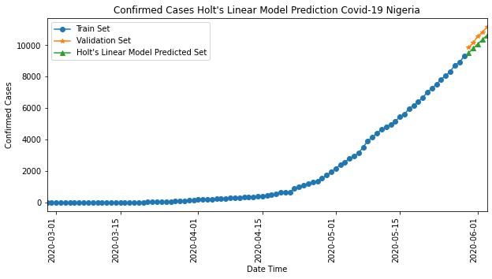

```python
plt.figure(figsize=(10,5))
plt.plot(model_train.Confirmed,label="Train Set",marker='o')
valid.Confirmed.plot(label="Validation Set",marker='*')
y_pred.Holt.plot(label="Holt's Linear Model Predicted Set",marker='^')
plt.ylabel("Confirmed Cases")
plt.xlabel("Date Time")
plt.title("Confirmed Cases Holt's Linear Model Prediction Covid-19 Nigeria")
plt.xticks(rotation=90)
plt.legend()
```

```python
holt_new_prediction=[]
for i in range(1,18):
    holt_new_prediction.append(holt.forecast((len(valid)+i))[-1])

model_predictions["Holt's Linear Model Prediction"]=holt_new_prediction
model_predictions.head(20)
```

|  | Date | Polynomial Regression Prediction | SVM Prediction | Holt's Linear Model Prediction |
| --- | --- | --- | --- | --- |
| 0 | 2020-06-04 | 11406.423481 | 17610.941709 | 10911.717761 |
| 1 | 2020-06-05 | 11699.589635 | 18717.890762 | 11189.085042 |
| 2 | 2020-06-06 | 11938.812156 | 19882.780819 | 11466.452323 |
| 3 | 2020-06-07 | 12100.642951 | 21108.013136 | 11743.819604 |
| 4 | 2020-06-08 | 12156.170057 | 22396.062848 | 12021.186884 |
| 5 | 2020-06-09 | 12070.186614 | 23749.480463 | 12298.554165 |
| 6 | 2020-06-10 | 11800.274780 | 25170.893382 | 12575.921446 |
| 7 | 2020-06-11 | 11295.798881 | 26663.007425 | 12853.288727 |
| 8 | 2020-06-12 | 10496.801803 | 28228.608381 | 13130.656007 |
| 9 | 2020-06-13 | 9332.798440 | 29870.563562 | 13408.023288 |
| 10 | 2020-06-14 | 7721.459727 | 31591.823384 | 13685.390569 |
| 11 | 2020-06-15 | 5567.180583 | 33395.422953 | 13962.757850 |
| 12 | 2020-06-16 | 2759.524806 | 35284.483674 | 14240.125131 |
| 13 | 2020-06-17 | -828.460279 | 37262.214871 | 14517.492411 |
| 14 | 2020-06-18 | -5342.066880 | 39331.915418 | 14794.859692 |
| 15 | 2020-06-19 | -10946.895220 | 41496.975396 | 15072.226973 |
| 16 | 2020-06-20 | -17830.975460 | 43760.877756 | 15349.594254 |

#### Holt's Winter Model

```python
model_train=nigeria_datewise.iloc[:int(nigeria_datewise.shape[0]*0.95)]
valid=nigeria_datewise.iloc[int(nigeria_datewise.shape[0]*0.95):]
y_pred=valid.copy()
```

```python
es=ExponentialSmoothing(np.asarray(model_train['Confirmed']),seasonal_periods=3,trend='mul', seasonal='add').fit()
```

```python
y_pred["Holt's Winter Model"]=es.forecast(len(valid))
```

```python
print("Root Mean Square Error for Holt's Winter Model: ",np.sqrt(mean_squared_error(y_pred["Confirmed"],y_pred["Holt's Winter Model"])))
```

```
Root Mean Square Error for Holt's Winter Model:  193.58580316241452
```

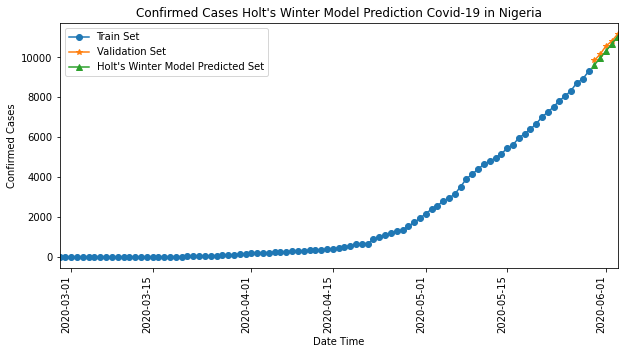

```python
plt.figure(figsize=(10,5))
plt.plot(model_train.Confirmed,label="Train Set",marker='o')
valid.Confirmed.plot(label="Validation Set",marker='*')
y_pred["Holt\'s Winter Model"].plot(label="Holt's Winter Model Predicted Set",marker='^')
plt.ylabel("Confirmed Cases")
plt.xlabel("Date Time")
plt.title("Confirmed Cases Holt's Winter Model Prediction Covid-19 in Nigeria")
plt.xticks(rotation=90)
plt.legend()
```

```python
holt_winter_new_prediction=[]
for i in range(1,18):
    holt_winter_new_prediction.append(es.forecast((len(valid)+i))[-1])
model_predictions["Holt's Winter Model Prediction"]=holt_winter_new_prediction
model_predictions.head(20)
```

|  | Date | Polynomial Regression Prediction | SVM Prediction | Holt's Linear Model Prediction | Holt's Winter Model Prediction |
| --- | --- | --- | --- | --- | --- |
| 0 | 2020-06-04 | 11406.423481 | 17610.941709 | 10911.717761 | 11440.149349 |
| 1 | 2020-06-05 | 11699.589635 | 18717.890762 | 11189.085042 | 11829.654256 |
| 2 | 2020-06-06 | 11938.812156 | 19882.780819 | 11466.452323 | 12235.932460 |
| 3 | 2020-06-07 | 12100.642951 | 21108.013136 | 11743.819604 | 12658.675052 |
| 4 | 2020-06-08 | 12156.170057 | 22396.062848 | 12021.186884 | 13084.096790 |
| 5 | 2020-06-09 | 12070.186614 | 23749.480463 | 12298.554165 | 13527.350497 |
| 6 | 2020-06-10 | 11800.274780 | 25170.893382 | 12575.921446 | 13988.158468 |
| 7 | 2020-06-11 | 11295.798881 | 26663.007425 | 12853.288727 | 14452.767587 |
| 8 | 2020-06-12 | 10496.801803 | 28228.608381 | 13130.656007 | 14936.363747 |
| 9 | 2020-06-13 | 9332.798440 | 29870.563562 | 13408.023288 | 15438.703292 |
| 10 | 2020-06-14 | 7721.459727 | 31591.823384 | 13685.390569 | 15946.068155 |
| 11 | 2020-06-15 | 5567.180583 | 33395.422953 | 13962.757850 | 16473.680312 |
| 12 | 2020-06-16 | 2759.524806 | 35284.483674 | 14240.125131 | 17021.333254 |
| 13 | 2020-06-17 | -828.460279 | 37262.214871 | 14517.492411 | 17575.347156 |
| 14 | 2020-06-18 | -5342.066880 | 39331.915418 | 14794.859692 | 18150.983362 |
| 15 | 2020-06-19 | -10946.895220 | 41496.975396 | 15072.226973 | 18748.075893 |
| 16 | 2020-06-20 | -17830.975460 | 43760.877756 | 15349.594254 | 19352.986647 |

### Facebook's Prophet Model

```python
prophet_c=Prophet(interval_width=0.95,weekly_seasonality=True,)
prophet_confirmed=pd.DataFrame(zip(list(nigeria_datewise.index),list(nigeria_datewise["Confirmed"])),columns=['ds','y'])
```

```python
prophet_c.fit(prophet_confirmed)
```

```
<fbprophet.forecaster.Prophet at 0x7f1f5c08a710>
```

```python
forecast_c=prophet_c.make_future_dataframe(periods=17)
forecast_confirmed=forecast_c.copy()
```

```python
confirmed_forecast=prophet_c.predict(forecast_c)
```

```python
print("Root Mean Squared Error for Prophet Model: ",np.sqrt(mean_squared_error(nigeria_datewise["Confirmed"],confirmed_forecast['yhat'].head(nigeria_datewise.shape[0]))))
```

```
Root Mean Squared Error for Prophet Model:  92.04113805304142
```

```
Figure(720x432)
```

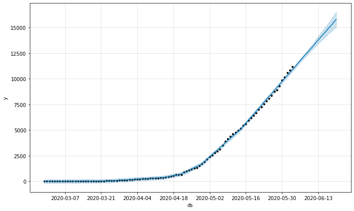

```python
print(prophet_c.plot(confirmed_forecast))
```

```
Figure(648x432)
```

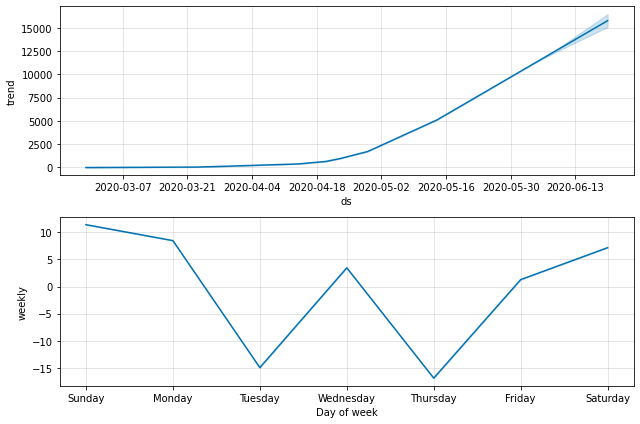

```python
print(prophet_c.plot_components(confirmed_forecast))
```

```python
model_predictions["Prophet's Prediction"]=list(confirmed_forecast["yhat"].tail(17))
model_predictions["Prophet's Upper Bound"]=list(confirmed_forecast["yhat_upper"].tail(17))
model_predictions.head(20)
```

|  | Date | Polynomial Regression Prediction | SVM Prediction | Holt's Linear Model Prediction | Holt's Winter Model Prediction | Prophet's Prediction | Prophet's Upper Bound |
| --- | --- | --- | --- | --- | --- | --- | --- |
| 0 | 2020-06-04 | 11406.423481 | 17610.941709 | 10911.717761 | 11440.149349 | 11148.831553 | 11334.729634 |
| 1 | 2020-06-05 | 11699.589635 | 18717.890762 | 11189.085042 | 11829.654256 | 11456.121762 | 11643.184117 |
| 2 | 2020-06-06 | 11938.812156 | 19882.780819 | 11466.452323 | 12235.932460 | 11751.132530 | 11935.756245 |
| 3 | 2020-06-07 | 12100.642951 | 21108.013136 | 11743.819604 | 12658.675052 | 12044.487517 | 12242.025539 |
| 4 | 2020-06-08 | 12156.170057 | 22396.062848 | 12021.186884 | 13084.096790 | 12330.660152 | 12534.004855 |
| 5 | 2020-06-09 | 12070.186614 | 23749.480463 | 12298.554165 | 13527.350497 | 12596.339628 | 12808.297254 |
| 6 | 2020-06-10 | 11800.274780 | 25170.893382 | 12575.921446 | 13988.158468 | 12903.862120 | 13146.240675 |
| 7 | 2020-06-11 | 11295.798881 | 26663.007425 | 12853.288727 | 14452.767587 | 13172.624447 | 13451.403218 |
| 8 | 2020-06-12 | 10496.801803 | 28228.608381 | 13130.656007 | 14936.363747 | 13479.914656 | 13817.004883 |
| 9 | 2020-06-13 | 9332.798440 | 29870.563562 | 13408.023288 | 15438.703292 | 13774.925424 | 14145.956434 |
| 10 | 2020-06-14 | 7721.459727 | 31591.823384 | 13685.390569 | 15946.068155 | 14068.280412 | 14458.039344 |
| 11 | 2020-06-15 | 5567.180583 | 33395.422953 | 13962.757850 | 16473.680312 | 14354.453047 | 14799.959848 |
| 12 | 2020-06-16 | 2759.524806 | 35284.483674 | 14240.125131 | 17021.333254 | 14620.132522 | 15106.532963 |
| 13 | 2020-06-17 | -828.460279 | 37262.214871 | 14517.492411 | 17575.347156 | 14927.655015 | 15459.778219 |
| 14 | 2020-06-18 | -5342.066880 | 39331.915418 | 14794.859692 | 18150.983362 | 15196.417341 | 15813.976428 |
| 15 | 2020-06-19 | -10946.895220 | 41496.975396 | 15072.226973 | 18748.075893 | 15503.707550 | 16162.247443 |
| 16 | 2020-06-20 | -17830.975460 | 43760.877756 | 15349.594254 | 19352.986647 | 15798.718318 | 16538.788735 |

## Summarizing Results of all Models

```python
model_predictions["Average of Predictions Models"]=model_predictions.mean(axis=1)
model_predictions.head(20)
```

|  | Date | Polynomial Regression Prediction | SVM Prediction | Holt's Linear Model Prediction | Holt's Winter Model Prediction | Prophet's Prediction | Prophet's Upper Bound | Average of Predictions Models |
| --- | --- | --- | --- | --- | --- | --- | --- | --- |
| 0 | 2020-06-04 | 11406.423481 | 17610.941709 | 10911.717761 | 11440.149349 | 11148.831553 | 11334.729634 | 12308.798915 |
| 1 | 2020-06-05 | 11699.589635 | 18717.890762 | 11189.085042 | 11829.654256 | 11456.121762 | 11643.184117 | 12755.920929 |
| 2 | 2020-06-06 | 11938.812156 | 19882.780819 | 11466.452323 | 12235.932460 | 11751.132530 | 11935.756245 | 13201.811089 |
| 3 | 2020-06-07 | 12100.642951 | 21108.013136 | 11743.819604 | 12658.675052 | 12044.487517 | 12242.025539 | 13649.610633 |
| 4 | 2020-06-08 | 12156.170057 | 22396.062848 | 12021.186884 | 13084.096790 | 12330.660152 | 12534.004855 | 14087.030265 |
| 5 | 2020-06-09 | 12070.186614 | 23749.480463 | 12298.554165 | 13527.350497 | 12596.339628 | 12808.297254 | 14508.368103 |
| 6 | 2020-06-10 | 11800.274780 | 25170.893382 | 12575.921446 | 13988.158468 | 12903.862120 | 13146.240675 | 14930.891812 |
| 7 | 2020-06-11 | 11295.798881 | 26663.007425 | 12853.288727 | 14452.767587 | 13172.624447 | 13451.403218 | 15314.815047 |
| 8 | 2020-06-12 | 10496.801803 | 28228.608381 | 13130.656007 | 14936.363747 | 13479.914656 | 13817.004883 | 15681.558246 |
| 9 | 2020-06-13 | 9332.798440 | 29870.563562 | 13408.023288 | 15438.703292 | 13774.925424 | 14145.956434 | 15995.161740 |
| 10 | 2020-06-14 | 7721.459727 | 31591.823384 | 13685.390569 | 15946.068155 | 14068.280412 | 14458.039344 | 16245.176932 |
| 11 | 2020-06-15 | 5567.180583 | 33395.422953 | 13962.757850 | 16473.680312 | 14354.453047 | 14799.959848 | 16425.575765 |
| 12 | 2020-06-16 | 2759.524806 | 35284.483674 | 14240.125131 | 17021.333254 | 14620.132522 | 15106.532963 | 16505.355392 |
| 13 | 2020-06-17 | -828.460279 | 37262.214871 | 14517.492411 | 17575.347156 | 14927.655015 | 15459.778219 | 16485.671232 |
| 14 | 2020-06-18 | -5342.066880 | 39331.915418 | 14794.859692 | 18150.983362 | 15196.417341 | 15813.976428 | 16324.347560 |
| 15 | 2020-06-19 | -10946.895220 | 41496.975396 | 15072.226973 | 18748.075893 | 15503.707550 | 16162.247443 | 16006.056339 |
| 16 | 2020-06-20 | -17830.975460 | 43760.877756 | 15349.594254 | 19352.986647 | 15798.718318 | 16538.788735 | 15494.998375 |